# Assignment 1 - Reproducible Research

PRO

29 de octubre de 2016

## Loading and preprocessing the data

1. Load the data (i.e. read.csv())

```r
fichero<- paste(dir, "activity.csv", sep="/")
file_o<- read.csv(fichero)
file<- file_o[!is.na(file_o$steps),]
```

2. Process/transform the data (if necessary) into a format suitable for your analysis

```r
file$date<-as.Date(file$date)
file_o$date<-as.Date(file_o$date)
```

## What is mean total number of steps taken per day?

1. Calculate the total number of steps taken per day

```r
stepday<-data.frame(aggregate(file$steps, list(file$date), sum))
colnames(stepday)<-c("Date", "Step")
```

2. If you do not understand the difference between a histogram and a barplot, research the difference between them. Make a histogram of the total number of steps taken each day

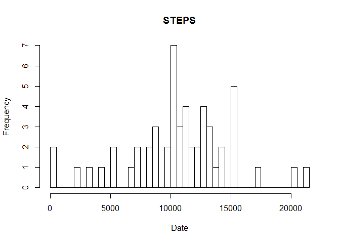

```r
hist(stepday$Step, freq=TRUE, breaks=53, xlab="Date",main="STEPS")
```

3. Calculate and report the mean and median of the total number of steps taken per day

```r
stepday_avg<-data.frame(aggregate(file$steps, list(file$date), mean))
colnames(stepday_avg)<- c("date", "steps")

stepday_med<-data.frame(aggregate(file$steps, list(file$date), median))
colnames(stepday_avg)<- c("date", "steps")

print(stepday_avg)
```

```
##          date      steps
## 1  2012-10-02  0.4375000
## 2  2012-10-03 39.4166667
## 3  2012-10-04 42.0694444
## 4  2012-10-05 46.1597222
## 5  2012-10-06 53.5416667
## 6  2012-10-07 38.2465278
## 7  2012-10-09 44.4826389
## 8  2012-10-10 34.3750000
## 9  2012-10-11 35.7777778
## 10 2012-10-12 60.3541667
## 11 2012-10-13 43.1458333
## 12 2012-10-14 52.4236111
## 13 2012-10-15 35.2048611
## 14 2012-10-16 52.3750000
```

[output cut: 39 more lines]

```r
print(stepday_med)
```

```
##       Group.1 x
## 1  2012-10-02 0
## 2  2012-10-03 0
## 3  2012-10-04 0
## 4  2012-10-05 0
## 5  2012-10-06 0
## 6  2012-10-07 0
## 7  2012-10-09 0
## 8  2012-10-10 0
## 9  2012-10-11 0
## 10 2012-10-12 0
## 11 2012-10-13 0
## 12 2012-10-14 0
## 13 2012-10-15 0
## 14 2012-10-16 0
```

[output cut: 39 more lines]

## What is the average daily activity pattern?

1. Make a time series plot (i.e. type = “l”) of the 5-minute interval (x-axis) and the average number of steps taken, averaged across all days (y-axis)

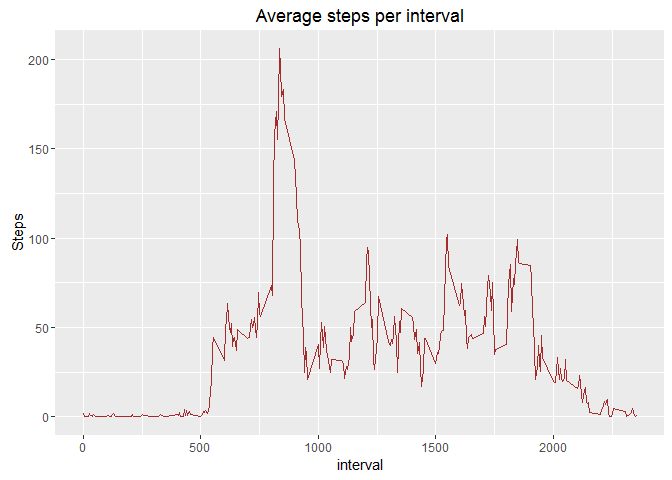

```r
intday<- data.frame(aggregate(file$steps,list(file$interval), mean))
colnames(intday)<-c("interval", "steps")

h <- ggplot(data=intday,aes(interval,steps))
h+geom_line(col="brown")+ggtitle("Average steps per interval")+xlab("interval")+ylab("Steps")
```

2.Which 5-minute interval, on average across all the days in the dataset, contains the maximum number of steps?

```r
intmax<- intday[intday$steps==max(intday$steps),2]
```

[output not shown]

## Imputing missing values

1. Calculate and report the total number of missing values in the dataset (i.e. the total number of rows with NAs)

```r
number_missing<-sum(is.na(file_o$steps))
```

Initial number of missing: 2304

2. Devise a strategy for filling in all of the missing values in the dataset. The strategy does not need to be sophisticated. For example, you could use the mean/median for that day, or the mean for that 5-minute interval, etc.

```r
nas <- is.na(file_o$steps)
file_o$steps[nas] <- intday[match(intday$interval, file_o$interval),2]

number_missing<-sum(is.na(file_o$steps))
```

Final number of missing: 0

3. Create a new dataset that is equal to the original dataset but with the missing data filled in.

```r
new_file <- file_o
number_missing<-sum(is.na(new_file$steps))
```

Number of missing: 0

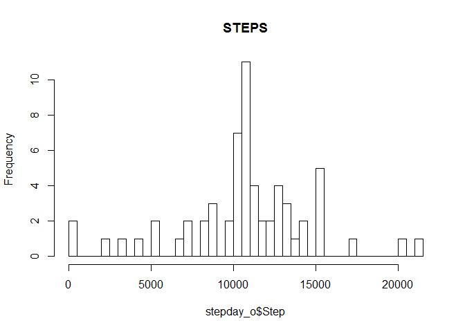

```r
stepday_o<-data.frame(aggregate(file_o$steps, list(file_o$date), sum))
colnames(stepday_o)<-c("Date", "Step")
hist(stepday_o$Step, freq=TRUE, breaks=53, main="STEPS")
```

# Are there differences in activity patterns between weekdays and weekends?

1. Create a new factor variable in the dataset with two levels - “weekday” and “weekend” indicating whether a given date is a weekday or weekend day.

```r
weekdays1 <- c('lunes', 'martes', 'miercoles', 'jueves', 'viernes')

file_o$weekdate <- factor((weekdays(file_o$date) %in% weekdays1),
                          levels=c(FALSE, TRUE), labels=c('weekend', 'weekday'))
```

2. Make a panel plot containing a time series plot (i.e. type = “l”) of the 5-minute interval (x-axis) and the average number of steps taken, averaged across all weekday days or weekend days (y-axis). See the README file in the GitHub repository to see an example of what this plot should look like using simulated data.

[figure not shown]

```r
ggplot(file_o, aes(interval, steps)) +
  geom_line() +
  facet_grid(weekdate~ .) +
  xlab("interval") +
  ylab("average number of steps")
```